# Projekt_grupowanie

Dawid Skowron

2023-06-07

## Opis danych

Dane zawarte w zbiorze zawierają recenzje wystawione przez użytkwników portalu Google. Dane te w pierwszej kolumnie zawierają indeks, a w każdej innej kolumnie kategorie danego miejsca i średnią ocenę jaką użytkownik wystawia dla danej kategorii. Co warto również zaznaczyć przedział wystawianych ocen zawiera się w skali od 0 do 5 gwiazdek. Oprócz danych źródłowych twórca zbioru załączył również legendę w osobnym pliku, która zostanie wykorzystana przy profilowaniu, by móc zastąpić nazwy kolumn na odpowiednie nazwy kategorii.

## Pobieranie danych.

```r
reviews <- read.csv("./google_review_ratings.csv", sep=",", header=TRUE,dec=".")
head(reviews)
```

|  | User | Category.1 | Category.2 | Category.3 | Category.4 | Category.5 | Category.6 | Category.7 | Category.8 | Category.9 | Category.10 | Category.11 | Category.12 | Category.13 | Category.14 | Category.15 | Category.16 | Category.17 | Category.18 | Category.19 | Category.20 | Category.21 | Category.22 | Category.23 | Category.24 | X |
| --- | --- | --- | --- | --- | --- | --- | --- | --- | --- | --- | --- | --- | --- | --- | --- | --- | --- | --- | --- | --- | --- | --- | --- | --- | --- | --- |
| 1 | User 1 | 0 | 0.0 | 3.63 | 3.65 | 5 | 2.92 | 5 | 2.35 | 2.33 | 2.64 | 1.7 | 1.69 | 1.70 | 1.72 | 1.74 | 0.59 | 0.5 | 0 | 0.5 | 0 | 0 | 0 | 0 | 0 | NA |
| 2 | User 2 | 0 | 0.0 | 3.63 | 3.65 | 5 | 2.92 | 5 | 2.64 | 2.33 | 2.65 | 1.7 | 1.69 | 1.70 | 1.72 | 1.74 | 0.59 | 0.5 | 0 | 0.5 | 0 | 0 | 0 | 0 | 0 | NA |
| 3 | User 3 | 0 | 0.0 | 3.63 | 3.63 | 5 | 2.92 | 5 | 2.64 | 2.33 | 2.64 | 1.7 | 1.69 | 1.70 | 1.72 | 1.74 | 0.59 | 0.5 | 0 | 0.5 | 0 | 0 | 0 | 0 | 0 | NA |
| 4 | User 4 | 0 | 0.5 | 3.63 | 3.63 | 5 | 2.92 | 5 | 2.35 | 2.33 | 2.64 | 1.73 | 1.69 | 1.70 | 1.72 | 1.74 | 0.59 | 0.5 | 0 | 0.5 | 0 | 0 | 0 | 0 | 0 | NA |
| 5 | User 5 | 0 | 0.0 | 3.63 | 3.63 | 5 | 2.92 | 5 | 2.64 | 2.33 | 2.64 | 1.7 | 1.69 | 1.70 | 1.72 | 1.74 | 0.59 | 0.5 | 0 | 0.5 | 0 | 0 | 0 | 0 | 0 | NA |
| 6 | User 6 | 0 | 0.0 | 3.63 | 3.63 | 5 | 2.92 | 5 | 2.63 | 2.33 | 2.65 | 1.71 | 1.69 | 1.69 | 1.72 | 1.74 | 0.59 | 0.5 | 0 | 0.5 | 0 | 0 | 0 | 0 | 0 | NA |

## Sprawdzenie przebiegu pobierania danych - czy dane zostały zaimportowane w sposób poprawny.

```r
summary(reviews)
```

```
##      User             Category.1      Category.2      Category.3
##  Length:5456        Min.   :0.000   Min.   :0.000   Min.   :0.000
##  Class :character   1st Qu.:0.920   1st Qu.:1.360   1st Qu.:1.540
##  Mode  :character   Median :1.340   Median :1.905   Median :2.060
##                     Mean   :1.456   Mean   :2.320   Mean   :2.489
##                     3rd Qu.:1.810   3rd Qu.:2.683   3rd Qu.:2.740
##                     Max.   :5.000   Max.   :5.000   Max.   :5.000
##
##    Category.4      Category.5      Category.6      Category.7
##  Min.   :0.830   Min.   :1.120   Min.   :1.110   Min.   :1.120
##  1st Qu.:1.730   1st Qu.:1.770   1st Qu.:1.790   1st Qu.:1.930
##  Median :2.460   Median :2.670   Median :2.680   Median :3.230
##  Mean   :2.797   Mean   :2.959   Mean   :2.893   Mean   :3.351
##  3rd Qu.:4.093   3rd Qu.:4.312   3rd Qu.:3.840   3rd Qu.:5.000
##  Max.   :5.000   Max.   :5.000   Max.   :5.000   Max.   :5.000
##
##    Category.8      Category.9     Category.10    Category.11
##  Min.   :0.860   Min.   :0.840   Min.   :0.810   Length:5456
##  1st Qu.:1.620   1st Qu.:1.800   1st Qu.:1.640   Class :character
##  Median :2.170   Median :2.800   Median :2.680   Mode  :character
##  Mean   :2.541   Mean   :3.126   Mean   :2.833
##  3rd Qu.:3.190   3rd Qu.:5.000   3rd Qu.:3.530
##  Max.   :5.000   Max.   :5.000   Max.   :5.000
##
##   Category.12     Category.13     Category.14     Category.15
##  Min.   :0.780   Min.   :0.770   Min.   :0.760   Min.   :0.000
##  1st Qu.:1.290   1st Qu.:1.190   1st Qu.:1.030   1st Qu.:0.860
##  Median :1.690   Median :1.610   Median :1.490   Median :1.330
##  Mean   :2.078   Mean   :2.126   Mean   :2.191   Mean   :2.207
##  3rd Qu.:2.285   3rd Qu.:2.360   3rd Qu.:2.740   3rd Qu.:4.440
##  Max.   :5.000   Max.   :5.000   Max.   :5.000   Max.   :5.000
##  NA's   :1
##   Category.16     Category.17      Category.18      Category.19
##  Min.   :0.000   Min.   :0.0000   Min.   :0.0000   Min.   :0.0000
##  1st Qu.:0.690   1st Qu.:0.5800   1st Qu.:0.5300   1st Qu.:0.5200
##  Median :0.800   Median :0.7400   Median :0.6900   Median :0.6900
##  Mean   :1.193   Mean   :0.9492   Mean   :0.8224   Mean   :0.9698
##  3rd Qu.:1.160   3rd Qu.:0.9100   3rd Qu.:0.8400   3rd Qu.:0.8600
##  Max.   :5.000   Max.   :5.0000   Max.   :5.0000   Max.   :5.0000
##
##   Category.20    Category.21      Category.22     Category.23
##  Min.   :0.00   Min.   :0.0000   Min.   :0.000   Min.   :0.000
##  1st Qu.:0.54   1st Qu.:0.5700   1st Qu.:0.740   1st Qu.:0.790
##  Median :0.69   Median :0.7600   Median :1.030   Median :1.070
##  Mean   :1.00   Mean   :0.9658   Mean   :1.751   Mean   :1.531
##  3rd Qu.:0.86   3rd Qu.:1.0000   3rd Qu.:2.070   3rd Qu.:1.560
##  Max.   :5.00   Max.   :5.0000   Max.   :5.000   Max.   :5.000
##
##   Category.24          X
##  Min.   :0.000   Min.   :1.040
##  1st Qu.:0.880   1st Qu.:1.425
##  Median :1.290   Median :1.810
##  Mean   :1.561   Mean   :1.810
##  3rd Qu.:1.660   3rd Qu.:2.195
##  Max.   :5.000   Max.   :2.580
##  NA's   :1       NA's   :5454
```

## Usunięcie niepotrzebnych kolumn dla naszej analizy.

```r
reviews <- reviews[, !(names(reviews) %in% c("X", "User"))]
head(reviews)
```

|  | Category.1 | Category.2 | Category.3 | Category.4 | Category.5 | Category.6 | Category.7 | Category.8 | Category.9 | Category.10 | Category.11 | Category.12 | Category.13 | Category.14 | Category.15 | Category.16 | Category.17 | Category.18 | Category.19 | Category.20 | Category.21 | Category.22 | Category.23 | Category.24 |
| --- | --- | --- | --- | --- | --- | --- | --- | --- | --- | --- | --- | --- | --- | --- | --- | --- | --- | --- | --- | --- | --- | --- | --- | --- |
| 1 | 0 | 0.0 | 3.63 | 3.65 | 5 | 2.92 | 5 | 2.35 | 2.33 | 2.64 | 1.7 | 1.69 | 1.70 | 1.72 | 1.74 | 0.59 | 0.5 | 0 | 0.5 | 0 | 0 | 0 | 0 | 0 |
| 2 | 0 | 0.0 | 3.63 | 3.65 | 5 | 2.92 | 5 | 2.64 | 2.33 | 2.65 | 1.7 | 1.69 | 1.70 | 1.72 | 1.74 | 0.59 | 0.5 | 0 | 0.5 | 0 | 0 | 0 | 0 | 0 |
| 3 | 0 | 0.0 | 3.63 | 3.63 | 5 | 2.92 | 5 | 2.64 | 2.33 | 2.64 | 1.7 | 1.69 | 1.70 | 1.72 | 1.74 | 0.59 | 0.5 | 0 | 0.5 | 0 | 0 | 0 | 0 | 0 |
| 4 | 0 | 0.5 | 3.63 | 3.63 | 5 | 2.92 | 5 | 2.35 | 2.33 | 2.64 | 1.73 | 1.69 | 1.70 | 1.72 | 1.74 | 0.59 | 0.5 | 0 | 0.5 | 0 | 0 | 0 | 0 | 0 |
| 5 | 0 | 0.0 | 3.63 | 3.63 | 5 | 2.92 | 5 | 2.64 | 2.33 | 2.64 | 1.7 | 1.69 | 1.70 | 1.72 | 1.74 | 0.59 | 0.5 | 0 | 0.5 | 0 | 0 | 0 | 0 | 0 |
| 6 | 0 | 0.0 | 3.63 | 3.63 | 5 | 2.92 | 5 | 2.63 | 2.33 | 2.65 | 1.71 | 1.69 | 1.69 | 1.72 | 1.74 | 0.59 | 0.5 | 0 | 0.5 | 0 | 0 | 0 | 0 | 0 |

## Przygotowywanie zbioru pod proces grupowania: pominięcie braków danych, ustawienie odpowiedniego typu wartości oraz przeskalowanie danych.

```r
reviews<- na.omit(reviews)
reviews$Category.11 <- as.numeric(reviews$Category.11)
reviews_normal <- scale(reviews)
```

## Sprawdzenie rozkładu zmiennych.

```r
library(reshape)
meltData <- melt(reviews_normal)
```

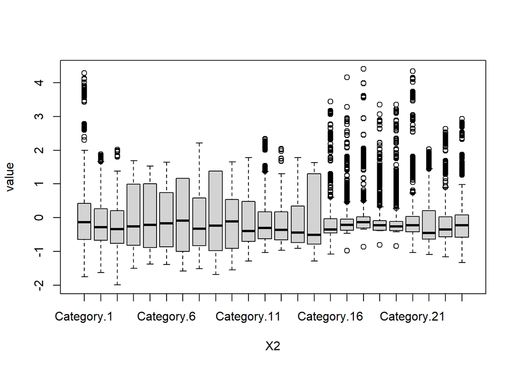

```r
boxplot(data=meltData, value~X2)
```

## Pierwszy etap, który pozwoli na określenie odpowiedniej liczby klastrów - wykres łokcia.

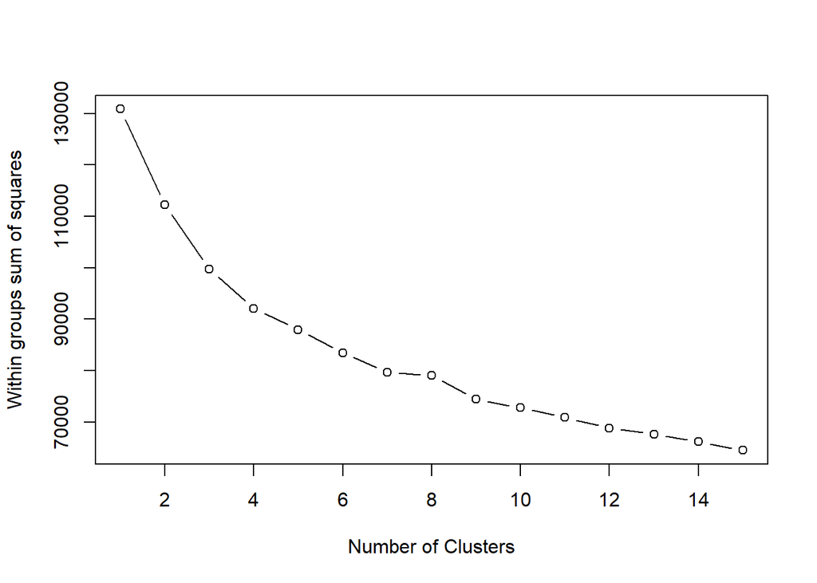

```r
wss <- (nrow(reviews_normal)-1)*sum(apply(reviews_normal,2,var))
for (i in 2:15) wss[i] <- sum(kmeans(reviews_normal, centers=i)$withinss)
plot(1:15, wss, type="b", xlab="Number of Clusters", ylab="Within groups sum of squares")
```

## Bazując na powyższym wykresie łokcia sprawdzamy grupowanie dla 4 klastrów.

```r
km <- kmeans(reviews_normal, 4)
```

## Wykres klastrów pierwszy.

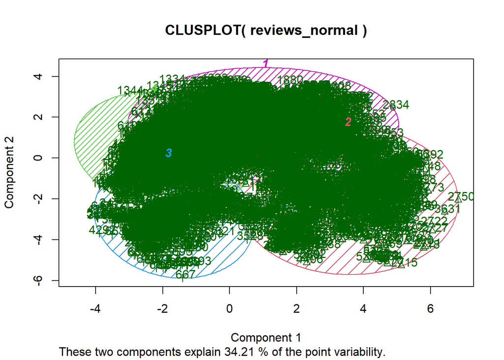

```r
library(cluster)
clusplot(reviews_normal, km$cluster, color=TRUE, shade=T, labels=2, lines=0)
```

## Wykres klastrów drugi.

```r
library(factoextra)
```

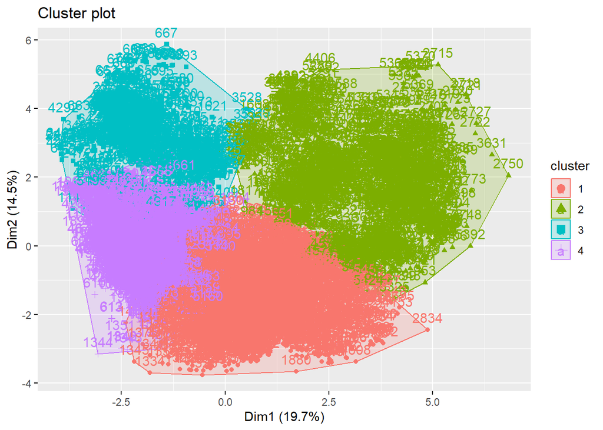

```r
fviz_cluster(km, data = reviews_normal)
```

## Dodatkowo sprawdzamy czy na pewno liczba klastrów równa 4 jest odpowiednia przy pomocy dendogramu.

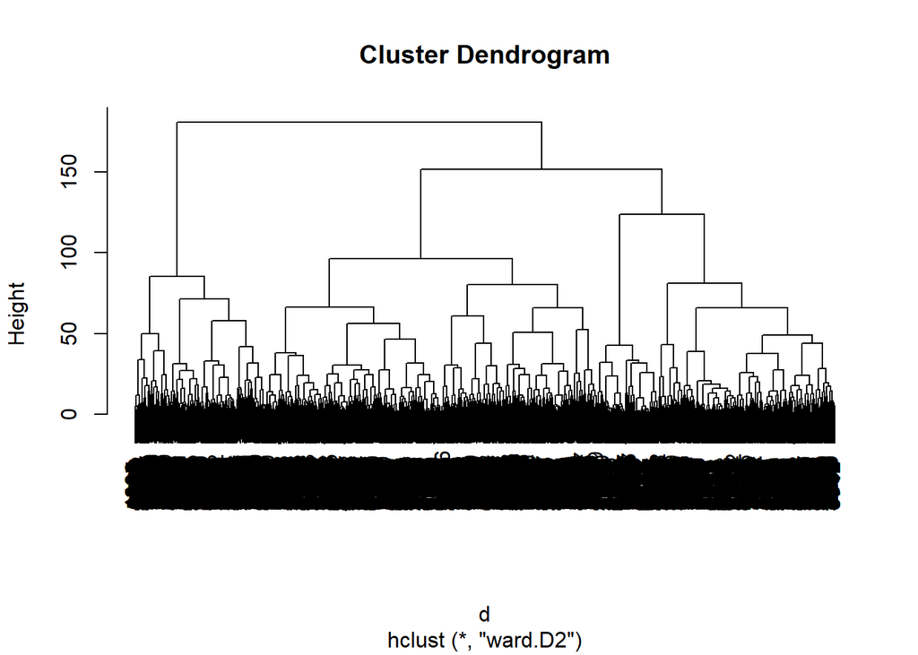

```r
d <- dist(reviews_normal, method = "euclidean") #odleglosc euklidesowa
fit <- hclust(d, method="ward.D2") # odleglosc miedzy klastrami
plot(fit)
```

# Wykres Silhouetta dla naszego przypadku.

```
##   cluster size ave.sil.width
## 1       1 1990          0.09
## 2       2 1011          0.13
## 3       3  608          0.26
## 4       4 1845          0.17
```

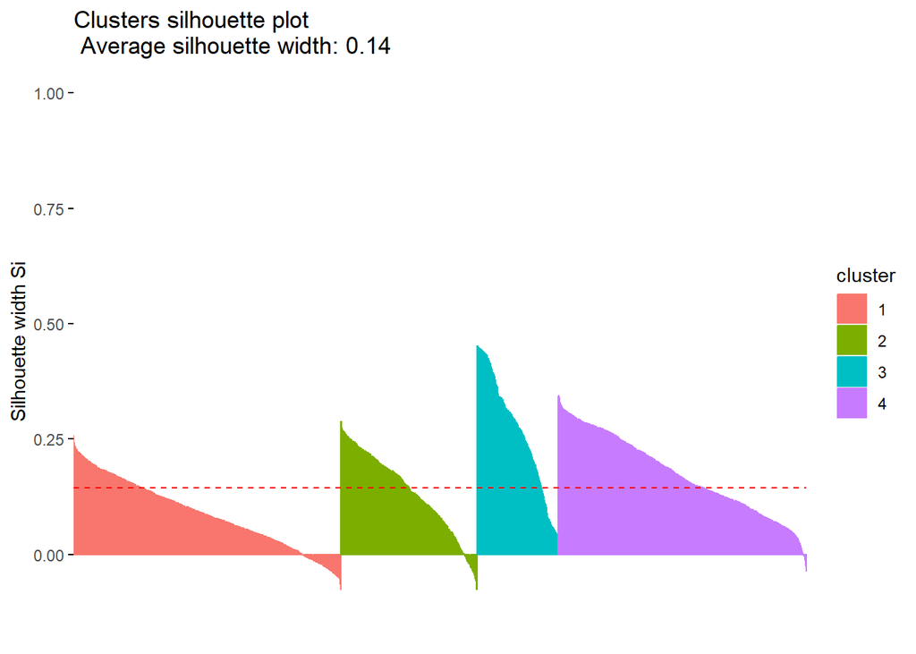

```r
d <- dist(reviews_normal, method = "euclidean")
fviz_silhouette(silhouette(km$cluster, d))
```

## Zmiana nazw kolumn by móc sprofilować recenzentów.

```r
colnames(reviews) <- c("churches", "resorts", "beaches", "parks", "theatres", "museums", "malls", "zoo", "restaurants", "pubs/bars", "local services", "burger/pizza shops", "hotels/other lodgings", "juice bars", "art galleries", "dance clubs", "swimming pools", "gyms", "bakeries", "beauty and spas", "cafes", "view points", "monuments", "gardens")
```

## Otatecznie profilujemy naszych klientów.

```r
library(flexclust)
```

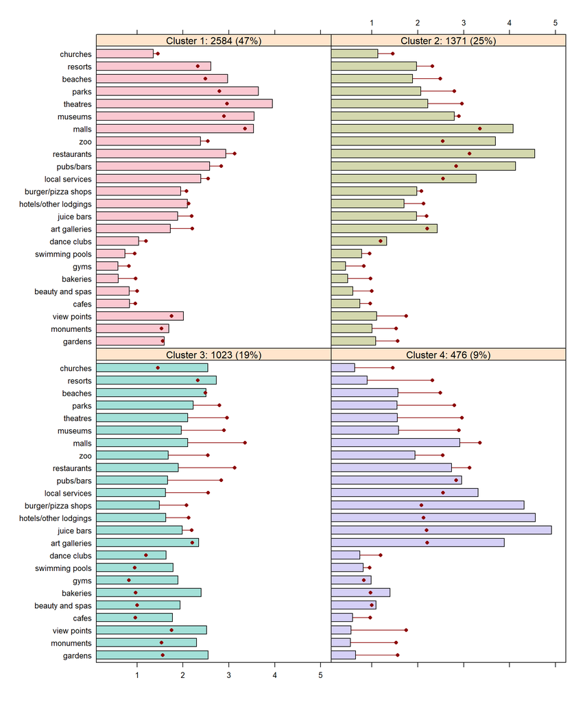

```r
barchart(fit, reviews, k =4)
```

Profilowanie

Cluster 1: Jest to najbardziej liczny klaster ponieważ stanowi aż 47% przypadków w naszym zbiorze. Recenzenci w tym klastrze posiadają najbardziej zbliżone recenzje do średnich dla całego zbioru. Wystawiają oni bardzo niskie oceny w takich miejscach jak: siłownie, piekarnie, parki wodne. Natomiast wystawiają bardzo wysokie noty w miejscach takich jak: teatry, parki czy też muzea.

Cluster 2: Drugi najbardziej liczny klaster. Zauważyć można podobieństwo względem poprzedniego klastra jeżeli chodzi o wystawiane recenzje. Jednakże osoby te chętnie pozostawiają wysokie oceny w takich miejscach jak: restauracje, bary, zoo czy też galerie handlowe. W kontekście reszty klastrów wystawiają oni najniższe oceny w takich miejscach jak siłownie i piekarnie.

Cluster 3: Osoby należące do tego klastra w odróżnieniu od innych w żadnym miejscu nie pozostawiają opinii poniżej jednej gwiazdki. Recenzje wystawiane przez nich mieszczą się w granicy od 1 gwiazdki do 3 i ciężko zauważyć znaczące odchylenia pod względem oceny dla danego miejsca. Mimo to zauważyć można iż osoby te pozostawiają po sobie najwyższe noty w miejscach takich jak np. kościoły, parki wodne, ogrody czy też pominiki. Wystawiają oni również najniżej punktowane opinie, w porównaniu do osób należących do innych klastrów, w miejscach takich jak: restauracje, bary oraz burgerownie /pizzerie.

Cluster 4: Najmniej liczny klaster, zawierający najabrdziej skrajne opinie gdyż osoby te należące do niego wystawiają bardzo niskie oceny w takich miejscach jak np. kościoły, kawiarnie, punkty widokowe, pominiki, ogrody, muzea, teatry, plaże i parki. Mimo tego iż osoby te wystawiają tak wiele negatywnych opinii w wielu miejscach, zauważyć można iż pozostawiają oni bardzo wysokie oceny po odwiedzeniu takich miejsc jak: hotele, bary z sokami, burgerownie/pizzerie i galerie sztuki.